# Genomics Project Report

##### Per sequence GC content: pass

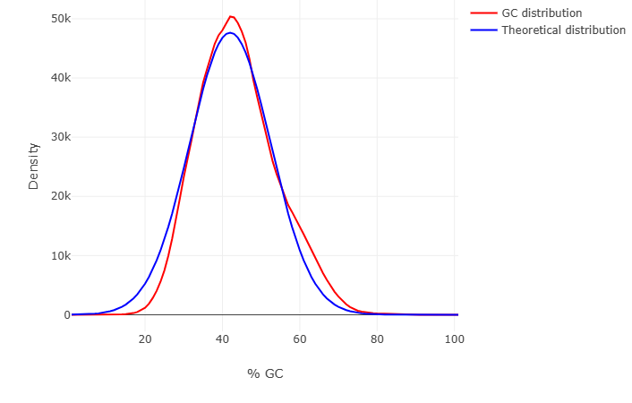

##### Per base N content : pass

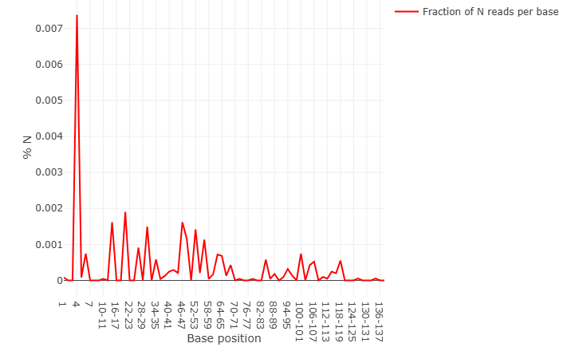

##### Sequence Length Distribution : warn

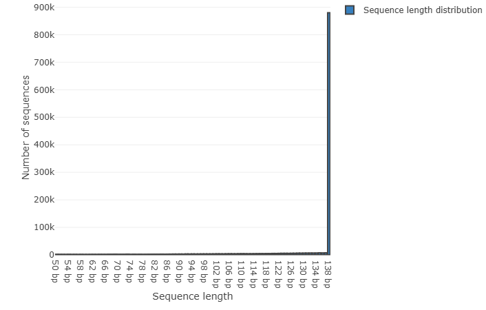

##### Sequence Duplication Levels : warn

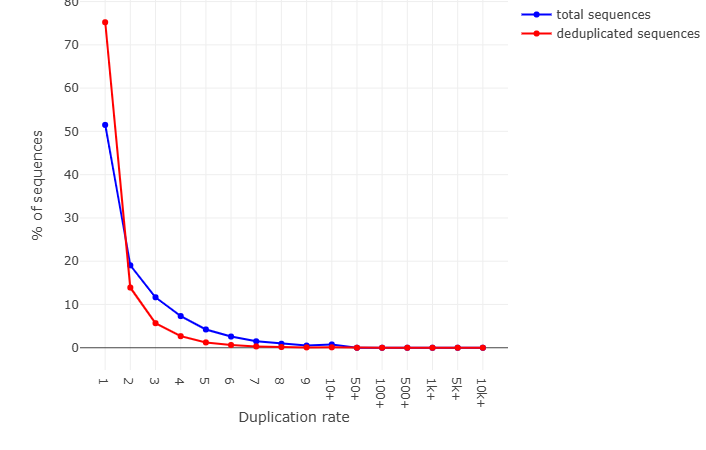

##### Overrepresented sequences : pass

**No overrepresented sequences**

##### Adapter Content : pass

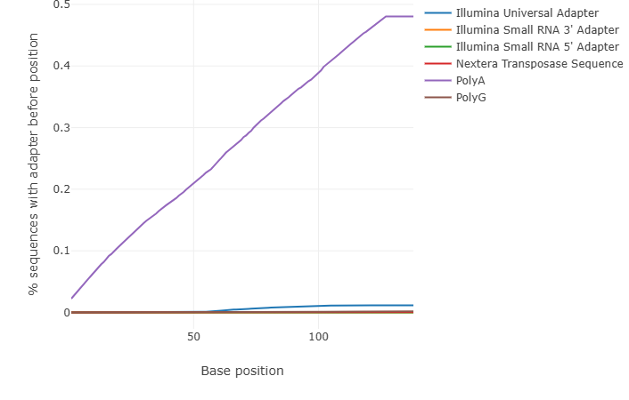

# Read Mapping

## Mapping with BWA

Filtered reads were aligned to the appropriate human reference genome using a short-read aligner.

```
Map with BWA-MEM - map medium and long reads (> 100 bp) against reference genome
(Galaxy Version 0.7.19)
```

**Tool Parameters**

| Input Parameter | Value |
| --- | --- |
| Will you select a reference genome from your history or use a built-in index? | cached |
| Using reference genome | hg38 |
| Single or Paired-end reads | paired |
| Select first set of reads |  |
| Select second set of reads |  |
| Enter mean, standard deviation, max, and min for insert lengths. | Not available. |
| Set read groups information? | do_not_set |
| Select analysis mode | illumina |
| BAM sorting mode | Sort by chromosomal coordinates |

### Expected coverage

Key alignment metrics such as mapping rate and coverage were evaluated.

A sequence’s coverage or read depth is the average amount of reads of each region in a given genome. To calculate the coverage we can use the formula `C = LN/G`, where `C = coverage`, `L = read length`, `N = number of reads` and `G = captured region`. This results in an expected or estimated coverage, as many reads could not be distributed evenly.

```r
Coverage <- function(readLength, readAmount, capturedRegion){
  (readLength * readAmount) / capturedRegion
}
```

```r
# Our expected coverage on CardioPanel
#
# 50 min. & 138 max. sequence length
# 1206159 total sequences, times 2 strands
# 320000 bases for the CarioPanel
Coverage(88, 1206159 * 2, 320000)
```

```
## [1] 663.3874
```

```r
# "Max Illumina sequencer coverage on CardioPanel
#
# 300 max Illumina sequence length
# 25000000 max Illumina reads
# 320000 bases for the CardioPanel
Coverage(300, 25000000, 320000)
```

```
## [1] 23437.5
```

The resulting expected read depth is ~ 663. Which means spotted DNA variants should be of high confidence. However, the actual coverage of each region should be also checked after the following mapping steps.

### Marking Duplicate Mapped Reads

Before analyzing differences between the reference genome and our patient sample, duplicate mapped reads must be identified. Duplicates arise from PCR amplification bias (multiple copies of the same fragment) or optical artifacts during sequencing, and if unaddressed, can lead to false positive variant calls and inaccurate coverage estimates.

We used `MarkDuplicates` tool on the coordinate-sorted BAM files from the previous mapping step. The algorithm identifies duplicate pairs by comparing read coordinates, orientations, and insert sizes, then adds a duplicate flag to each identified duplicate read. Importantly, reads are flagged but not removed, preserving data integrity while allowing downstream tools to ignore these flagged reads during analysis.

```
MarkDuplicates - examine aligned records in BAM datasets to locate duplicate molecules
(Galaxy Version 3.1.1.0)
```

**The output includes:**

A marked BAM file `.bam`: alignment data with duplicate flags

A BAM index file `.bai`: enables rapid random access for visualization

These files serve as input for the next step: visualizing the mapping data without the confounding effects of duplicates.

### Visualizing the Mapping Data

#### Integrative Genomics Viewer (IGV)

To visually inspect the mapped reads and identify potential variants, we used the **Integrative Genomics Viewer (IGV)**. This tool enabled visualization of read alignment, coverage depth, and nucleotide changes across target regions, using the BED file to navigate directly to genes of interest.

#### Reference Genome and Data Files

The reference genome used for visualization was **GRCh38/hg38** (Genome Reference Consortium Human Build 38), which provides a high-quality assembly of the human genome.

For this visualization step, we used two primary input files:

1. **Marked BAM file** (`dataset.bam`): Contains the aligned reads with duplicate flags, enabling accurate visualization without PCR bias.
2. **Target BED file** (`Reference-hg38.bed`): A interval file specifying all captured regions in the gene panel.

The BED file contains four columns specifying the chromosome, exon start and end positions, and gene name (e.g., PSEN2, LMNA), allowing us to navigate directly to regions of interest. This BED file served as a navigation guide, allowing us to rapidly zoom into specific genes of interest and examine their coverage and potential variants.

#### Variant Identification

Using the BED file to navigate, we examined two different genes of interest. Below are representative examples of variants identified in this analysis:

**Figure 1: PSEN2 Gene Region**

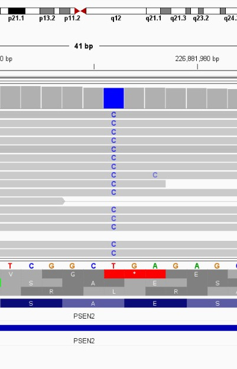

**Figure 2: LMNA Gene Region**

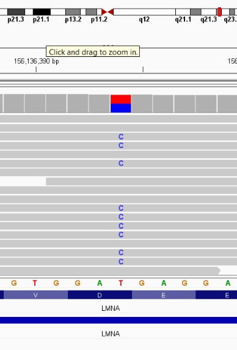

Visualization of the LMNA gene showing a heterozygous variant. The aligned reads display both reference and alternative alleles (mixed colors at the variant position), with approximately equal representation. Heterozygous variants in LMNA are known to be associated with dilated cardiomyopathy (DCM).

# Mapping Quality Control

In this section, we assessed the mapping coverage for all panel genes to evaluate mapping performance. As observed in IGV, coverage levels varied significantly across regions, ranging from very high (300+) to areas with only a few reads present, which can impact variant detection reliability. Using **R** with libraries commonly used in genetic research, we calculated and reported coverage statistics for all panel genes to quantitatively assess these variations and identify undercovered regions.

## Loading the BED-data

The first step is to load the BED file containing the exon coordinates of our panel genes. The file is tab-separated and has four columns: chromosome, start, end, and gene name. We will read it into R, assign proper column names, and then examine the distribution of exons across chromosomes.

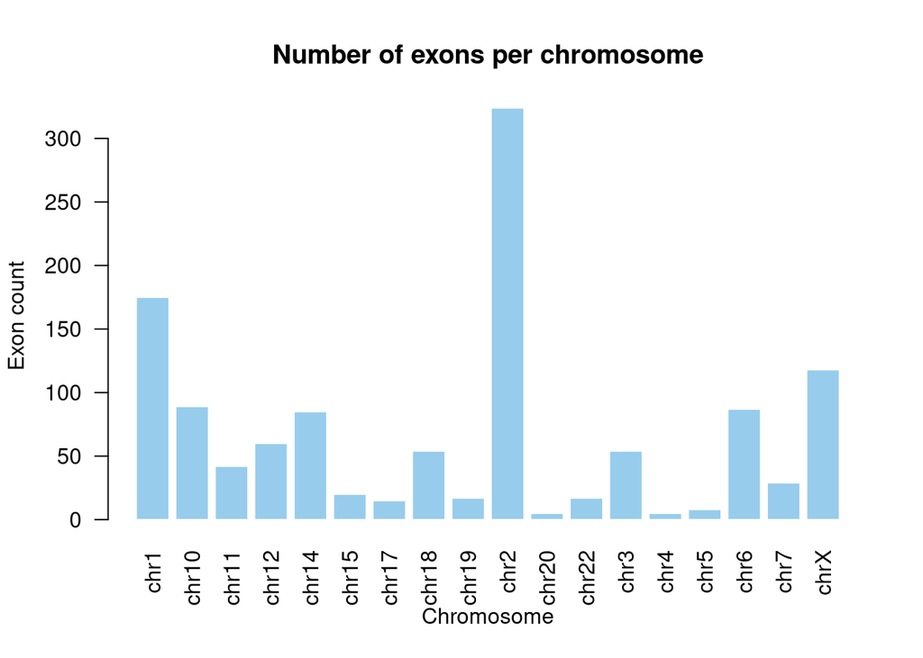

```r
bed_file <- "./Reference-hg38.bed"

exons <- read.table(bed_file, header = FALSE, sep = "\t", stringsAsFactors = FALSE)

colnames(exons) <- c("chromosome", "start", "end", "gene")

# Count exons per chromosome
exon_counts <- table(exons$chromosome)

# Plot the number of exons per chromosome
barplot(exon_counts,
        main = "Number of exons per chromosome",
        ylab = "Exon count",
        xlab = "Chromosome",
        las = 2,
        col = "#97cced",
        border = "white"
)
```

## BED-visualization

In this section, we visualized the distribution of genes across different chromosomes using the BED data. First, we reduced the data to unique chromosome-gene combinations, then counted the number of genes per chromosome and presented the results in a bar plot. This visualization provides a clear overview of how genes are distributed across chromosomes, helping to identify which chromosomes carry the most genes in our panel.

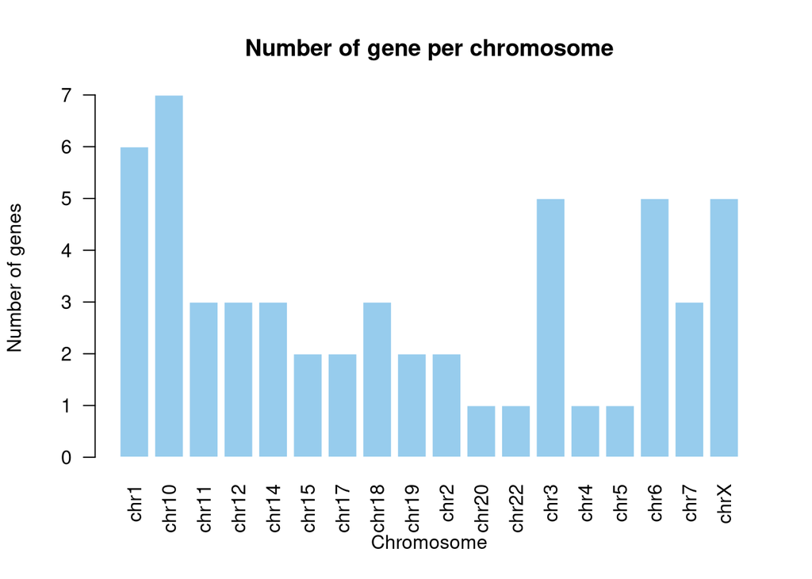

```r
chromosome_gene <- subset(exons, select = c(chromosome, gene))

uni_gene <- unique(chromosome_gene)

gene_counts <- table(uni_gene$chromosome)

barplot(gene_counts,
        main = "Number of gene per chromosome",
        ylab = "Number of genes",
        xlab = "Chromosome",
        las = 2,
         col = "#97cced",
        border = "white"
    )
```

## Bioconductor

Bioconductor is a repository containing over 1800 R packages specifically designed for analyzing high-throughput biological data, which we used throughout this assignment.

**Why Convert IRanges to GRanges?**

The IRanges object contains exon positions and lengths but lacks chromosome information, making it incomplete for genomic analysis. Converting to a GRanges object adds the chromosome context, creating a complete genomic coordinate system that properly locates each exon in the genome.

```r
# This package contains the 'IRanges', 'GRanges' and 'GRangesList' classes we will use
library(GenomicRanges)
```

```r
# Split the data by gene, resulting in a list with named elements
bed_splitted <- split(exons, exons$gene)
my_list <- list()

for (gene in names(bed_splitted)[1:55]) {
  data <- bed_splitted[[gene]]
  ranges <- IRanges(start = data$start, end = data$end, names = data$gene)
  granges <- GRanges(seqnames = data$chromosome, ranges = ranges)
  my_list[[gene]] <- granges
}

final_GRange_list <- GRangesList(my_list)
head(final_GRange_list)
```

```
## GRangesList object of length 6:
## $ABCC9
## GRanges object with 39 ranges and 0 metadata columns:
##         seqnames            ranges strand
##            <Rle>         <IRanges>  <Rle>
##   ABCC9    chr12 21801024-21801201      *
##   ABCC9    chr12 21805154-21805331      *
##   ABCC9    chr12 21805978-21806080      *
##   ABCC9    chr12 21807326-21807499      *
##   ABCC9    chr12 21809832-21809975      *
##     ...      ...               ...    ...
##   ABCC9    chr12 21915648-21915930      *
##   ABCC9    chr12 21916917-21917123      *
##   ABCC9    chr12 21925922-21926083      *
##   ABCC9    chr12 21933762-21933943      *
##   ABCC9    chr12 21936513-21936694      *
##   -------
##   seqinfo: 18 sequences from an unspecified genome; no seqlengths
##
## ...
## <5 more elements>
```

## Gene Lengths

```r
library(plotrix)
```

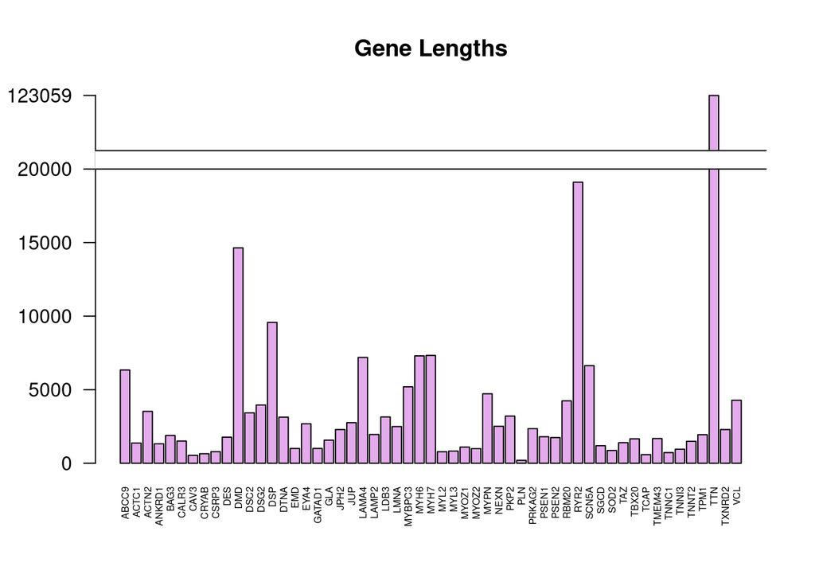

```r
geneLengths <- sum(width(ranges(final_GRange_list)))
# Originally 123059
geneLengths["TTN"] <- 25000

barplot(geneLengths, axes = F, cex.names = 0.5, las = 2, ylim = c(0, 25000), main = "Gene Lengths", col = "#e3abeb")
axis(2, at = c(0, 5000, 10000, 15000, 20000, 25000),
     labels = c("0", "5000", "10000", "15000", "20000", "123059"), las = 2)
axis.break(2, 20000, style = "gap", brw = 0.05)
```

## Loading the Mapped Reads

We used the output from the mapping step (the BAM file) to inspect the coverage of all mapped positions across our panel genes. The Rsamtools library provides the necessary functions to read and process this alignment data into GRanges objects for further analysis.

First, we used the *BamFile* function to create a reference to our BAM file and its index, which allowed us to access the alignment data efficiently without loading the entire file into memory. Then, to extract only our specific gene regions from the BED-data, we used the *ScanBamParam* function with GRanges objects to set the parameters for selection. Finally, we applied the *pileup* function to retrieve the coverage information for these regions, which returned the actual read counts at each position within our genes for downstream analysis. Here the pileup data for **TTN** gene.

```r
# Loading the RSamtools library
library(Rsamtools)
```

```r
#Example pileup on TTN gene
bam_file <- BamFile(file="./MapReads.bam", index = "./MapReads.bai")

TTN_gene <- final_GRange_list[["TTN"]]

ScanParam_gene <-ScanBamParam(which = TTN_gene)

pileup_data <- pileup(file = bam_file, scanBamParam = ScanParam_gene)

head(pileup_data)
```

```
##   seqnames       pos strand nucleotide count              which_label
## 1     chr2 178526992      +          G   219 chr2:178526992-178527327
## 2     chr2 178526992      -          G    68 chr2:178526992-178527327
## 3     chr2 178526993      +          A     2 chr2:178526992-178527327
## 4     chr2 178526993      +          T   215 chr2:178526992-178527327
## 5     chr2 178526993      -          T    68 chr2:178526992-178527327
## 6     chr2 178526994      +          A   218 chr2:178526992-178527327
```

## Pileup Processing

Here, we will obtain the pileup data for all our genes and store it in a single object `pileup_list`. This will allow us to calculate the average coverage for each gene and identify positions with low coverage that may require further inspection.

```r
pileup_list <- list()

for (gene in names(final_GRange_list)) {
  data <- final_GRange_list[[gene]]
  ScanParam_gene <-ScanBamParam(which = data)
  pileup_data <- pileup(file = bam_file, scanBamParam = ScanParam_gene)
  pileup_list[[gene]] <- pileup_data
}
#Compare with TTN pileup above
head(pileup_list[["TTN"]])
```

```
##   seqnames       pos strand nucleotide count              which_label
## 1     chr2 178526992      +          G   219 chr2:178526992-178527327
## 2     chr2 178526992      -          G    68 chr2:178526992-178527327
## 3     chr2 178526993      +          A     2 chr2:178526992-178527327
## 4     chr2 178526993      +          T   215 chr2:178526992-178527327
## 5     chr2 178526993      -          T    68 chr2:178526992-178527327
## 6     chr2 178526994      +          A   218 chr2:178526992-178527327
```

This table shows the raw sequencing data for every position in our genes. Each row represents one nucleotide position, telling us which chromosome it’s on, the exact location, which DNA strand the read came from, what base (A, T, G, or C) was detected, and how many times that base was seen. The last column just labels which gene the position belongs to. This data helps us see how well each region was covered during sequencing and spot any positions that might need a closer look.

## Coverage calculation and reporting

We calculated the per-position coverage for each gene using the *aggregate* function, which sums the count values for each unique position across all reads. For every gene, we then determined: the number of bases sequenced, the average coverage, the number of low-coverage positions (below 30), and the percentage of low-coverage positions. These four values were stored in a new data frame along with the gene name, and the final results were ordered by the percentage of low-coverage positions in descending order.

```r
per_position_coverage <- data.frame(Gene = character(),
                           NumBases = integer(),
                           AvgCoverage = numeric(),
                           LowCovPos = integer(),
                           LowCovPerc = numeric())

for (gene_name in names(pileup_list)) {

  gene_data <- pileup_list[[gene_name]]

  coverage <- aggregate(x = list(count = gene_data$count),
                       by = list(pos = gene_data$pos),
                       FUN = sum)

  num_bases <- nrow(coverage)
  avg_cov <- round(mean(coverage$count), digits = 1)
  low_cov_num <- sum(coverage$count < 30)
  low_cov_perc <- round((low_cov_num / num_bases) * 100, digits = 1)

  new_row <- list(Gene = gene_name,
                  NumBases = num_bases,
                  AvgCoverage = avg_cov,
                  LowCovPos = low_cov_num,
                  LowCovPerc = low_cov_perc)

  per_position_coverage <- rbind(per_position_coverage, new_row)

}

#All genes processed
print(per_position_coverage)
```

```
##      Gene NumBases AvgCoverage LowCovPos LowCovPerc
## 1   ABCC9     6339       247.8         0        0.0
## 2   ACTC1     1375       189.4        57        4.1
## 3   ACTN2     3527       182.9         0        0.0
## 4  ANKRD1     1322       229.8         0        0.0
## 5    BAG3     1892       205.1         0        0.0
## 6   CALR3     1511       241.4         0        0.0
## 7    CAV3      536       192.0         0        0.0
## 8   CRYAB      650       151.9         1        0.2
## 9   CSRP3      785       228.7         0        0.0
## 10    DES     1774       118.9       260       14.7
## 11    DMD    14643       246.6         0        0.0
## 12   DSC2     3427       236.5       110        3.2
## 13   DSG2     3959       238.0        86        2.2
## 14    DSP     9577       235.5         6        0.1
```

[output cut: 41 more lines]

Coverage analysis across the 55 cardiomyopathy genes shows that the majority **(40 genes)** have excellent sequencing coverage with **0%** low coverage positions. However, several genes show concerning coverage gaps. JPH2 has the poorest coverage with **(30.7%)** of the gene falling below acceptable thresholds, followed by GATAD1 **(21.3%)**, TPM1 **(16.8%)**, and PRKAG2 **(16.3%)**. Other genes with significant coverage issues include DES **(14.7%)**, JUP **(11.2%)**, and MYBPC3 **(10.5%)**. These genes with >10% low coverage warrant careful interpretation as potential variants in these poorly covered regions may be missed. In contrast, important large genes like TTN maintained excellent coverage throughout, increasing confidence in variant detection.

# Analysis of Variants

## Finding and Annotating Variants

Variant calling was performed to identify single nucleotide variants (SNVs) and small insertions/deletions (indels) from the aligned reads. We are interested in a single nucleotide variants (SNVs) only, thus we are using the default settings in the tool.

```
Call variants with LoFreq
(Galaxy Version 2.1.5+galaxy3)
```

**Tool Parameters**

| Input Parameter | Value |
| --- | --- |
| Input reads in BAM format |  |
| Choose the source for the reference genome | cached |
| Reference genome | hg38 |
| Call variants across | genome |
| Types of variants to call | Only SNVs |
| Variant calling parameters | false |
| Variant filter parameters | set_lofreq_standard |
| sig | 0.01 |
| bonf | dynamic |
| others | Empty. |

## VCF File Fitlering

```r
VCF_FILE <- read.delim("Call_variants.vcf", stringsAsFactors = FALSE , comment = "#")
head(VCF_FILE)
```

```
##   CHROM      POS ID REF ALT QUAL FILTER                                 INFO
## 1  chr1 27325641  .   A   G  144   PASS     DP=16;AF=0.3125;SB=0;DP4=9,2,5,0
## 2  chr1 71625045  .   C   T  147   PASS   DP=14;AF=0.428571;SB=0;DP4=8,0,6,0
## 3  chr1 71625166  .   C   A  517   PASS DP=31;AF=0.548387;SB=0;DP4=14,0,17,0
## 4  chr1 71625235  .   G   T  729   PASS DP=46;AF=0.543478;SB=1;DP4=14,7,18,7
## 5  chr1 77774432  .   T   C  425   PASS       DP=20;AF=0.65;SB=0;DP4=4,3,6,7
## 6  chr1 77917782  .   G   A 5119   PASS   DP=332;AF=0.5;SB=4;DP4=95,71,85,81
```

## VCF File Processing

To minimize false positive calls, variants were filtered using allele frequency. First we extract the allele frequency (AF) values from the VCF file. This AF data was subsequently incorporated as an additional column following the creation of GRanges objects.

```r
vcfInfo <- do.call(rbind, strsplit(VCF_FILE$INFO, ";"))

vcfInfo <- data.frame(vcfInfo)
names(vcfInfo) <- c("DP", "AF", "SB", "DP4")

alleleFreq <- as.numeric(gsub("AF=", x = vcfInfo$AF, ""))
```

Variants were subsequently filtered to retain only those with an allele frequency of ≥30%.

```r
vcfIRanges <- IRanges(start = VCF_FILE$POS, end = VCF_FILE$POS)

vcfGRanges <- GRanges(seqnames = VCF_FILE$CHROM, ranges = vcfIRanges )

mcols(vcfGRanges) <- DataFrame(AF = alleleFreq)

vcfGRangesFiltered <- vcfGRanges[vcfGRanges$AF >= 0.3]

vcfGRangesFiltered
```

```
## GRanges object with 1108 ranges and 1 metadata column:
##          seqnames    ranges strand |        AF
##             <Rle> <IRanges>  <Rle> | <numeric>
##      [1]     chr1  27325641      * |  0.312500
##      [2]     chr1  71625045      * |  0.428571
##      [3]     chr1  71625166      * |  0.548387
##      [4]     chr1  71625235      * |  0.543478
##      [5]     chr1  77774432      * |  0.650000
##      ...      ...       ...    ... .       ...
##   [1104]     chrX  76653828      * |  0.538462
##   [1105]     chrX 114758092      * |  1.000000
##   [1106]     chrX 144264053      * |  0.733333
##   [1107]     chrX 154412069      * |  1.000000
##   [1108]     chrX 154421359      * |  0.457143
##   -------
##   seqinfo: 26 sequences from an unspecified genome; no seqlengths
```

To identify all variants falling within exonic regions, an overlap analysis was performed using the `findOverlaps` function. The resulting output contains two columns: `queryHits` and `subjectHits.` The `queryHits` column indicates the rows from the VCF data that lie within an exon, representing the variants of interest. The `subjectHits` column corresponds not to individual exons but to genes, meaning a `subjectHits` value of 1 refers to a hit within any exon of the first gene.

```r
overlaps <- findOverlaps(vcfGRangesFiltered, final_GRange_list)
overlaps <- DataFrame(overlaps)
(overlaps)
```

```
## DataFrame with 129 rows and 2 columns
##     queryHits subjectHits
##     <integer>   <integer>
## 1          21          25
## 2          23          25
## 3          24          25
## 4          35          51
## 5          36          51
## ...       ...         ...
## 125      1085          11
## 126      1090          11
## 127      1097          11
## 128      1098          11
## 129      1107          45
```

After obtaining the row numbers of variants to retain, the filtered VCF file was reconstructed. This was achieved by reading the original VCF file with the `readLines` function. The header lines and variant rows were extracted separately, then recombined to generate the final filtered VCF file with `writeLines`.

```r
vcfLines <- readLines(con = file("./Call_variants.vcf"))

header_lines <- vcfLines[1:146]

variant_lines <- vcfLines[overlaps$queryHits + 147]

final_vcf <- c(header_lines, variant_lines)

writeLines(final_vcf, "filtered_variants.vcf")
```

### Variant Visualization

Two simple visualizations were created to explore the filtered variant dataset.

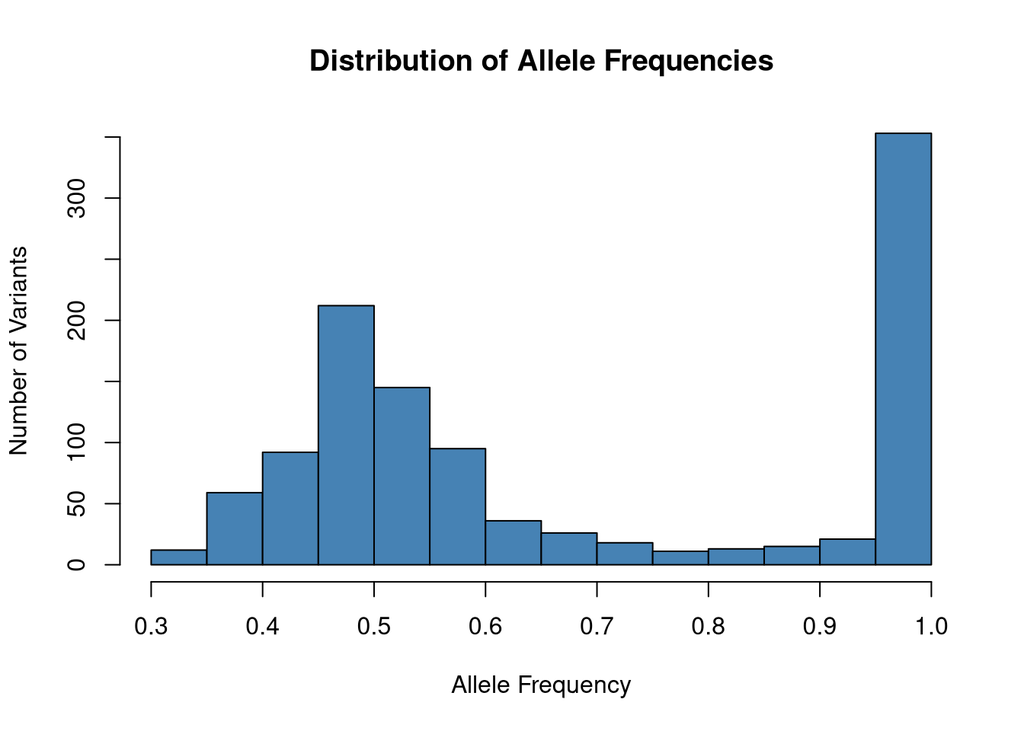

```r
hist(vcfGRangesFiltered$AF, breaks = 20, main = "Distribution of Allele Frequencies", ylim = c(0, 350),
     xlab = "Allele Frequency",
     ylab = "Number of Variants",
     col = "steelblue")
```

The two peaks in the allele frequency histogram correspond to the two possible zygosity states in a diploid genome:

- **50%**: Heterozygous variants, where one copy carries the alternative allele and the other carries the reference allele
- **100%**: Homozygous variants, where both copies carry the alternative allele

Next we can plot the number of variants per gene.

```r
# Loading the ggplot2 library
library(ggplot2)
```

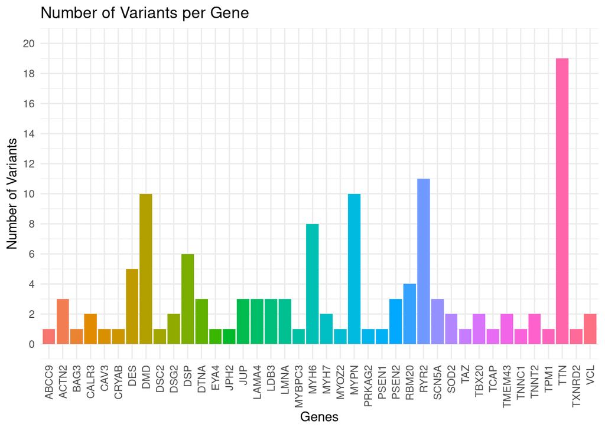

```r
variantFreq <- table(overlaps$subjectHits)

names(variantFreq) <- names(final_GRange_list)[as.integer(names(variantFreq))]

variantFreq <- data.frame(variantFreq)

names(variantFreq) <- c("gene_name", "variant_count")

ggplot(variantFreq, aes(x = gene_name, y = variant_count, fill = gene_name)) +
  geom_bar(stat = "identity", show.legend = FALSE) +
  labs(title = "Number of Variants per Gene", x = "Genes", y = "Number of Variants") +
  scale_y_continuous(breaks = seq(0, 20, by = 2)) +   # finer y‑axis breaks
  coord_cartesian(ylim = c(0, 20)) +
  theme_minimal() +
  theme(axis.text.x = element_text(angle = 90, hjust = 1, vjust = 0.5))  # vertical labels
```

Looking at the distribution of variants across genes, **TTN** had the highest number with 19 variants, followed by **RYR2** with 11. **MYPN** and **DMD** each had 10 variants, while **MYH6** had 8. A few other genes like **DSP** (6) and **DES** (5) also showed moderate variant counts. The rest of the genes had smaller numbers, mostly between 1 and 3 variants.

What’s interesting is that most of the genes with the highest variant counts are actually known to be involved in heart disease. So even though the variants are spread across many genes, the ones with the most hits tend to be those with known roles in cardiac function. This is not surprising, as our samples were obtained from patients with cardiomyopathy, so finding more variants in heart-disease-associated genes is expected.

# Variant Annotation

The filtered VCF file was uploaded to Galaxy for the subsequent annotation step to identify and characterize the genetic differences.

## SnpEff and SnpSift

Following variant calling with `LoFreq`, we performed three sequential annotation steps to add functional, clinical, and population-level information to our filtered VCF file.

**SnpEff – Functional Annotation**

We used `SnpEff` with the GRCh38.p14 genome reference to annotate our filtered VCF file. This tool adds functional predictions for each variant, including impact severity (HIGH, MODERATE, LOW, MODIFIER), gene names, transcript biotypes, and HGVS nomenclature. All annotation details are stored in the `ANN` field. The output consists of an annotated VCF file and a web-based summary report.

**SnpSift – dbSNP and ClinVar Annotation**

We ran `SnpSift` to add known variant identifiers and clinical significance data using the `dbSNP` database that includes `ClinVar` information. The `ID` column was populated with ClinVar identifiers, and the `INFO` field was expanded with clinical significance (CLNSIG), disease names (CLNDN), and review status (CLNREVSTAT) for known variants.

**SnpSift – dbNSFP Annotation**

We used `SnpSift` to annotate our VCF with the `dbNSFP` database, a comprehensive collection of over 300GB of integrated annotation sources. This step added population allele frequencies from gnomAD and ExAC, multiple in-silico prediction scores (including SIFT, PolyPhen, REVEL, CADD, and AlphaMissense), conservation metrics, and gene constraint information. The resulting file, `SnpVariants_Step3.vcf`, was used for subsequent filtering and analysis in Galaxy.

```bash
java -jar /data/datasets/dbNSFP/snpEff/SnpSift.jar DbNsfp -db /data/datasets/dbNSFP/snpEff/data/dbNSFP5.3.1a_grch38.gz -n SnpVariants_Step2.vcf > SnpVariants_Step3.vcf
```

**Annotation Summary**

```r
library(stringr)
```

```r
#Read metadata description fields from final vcf file
snpVcf <- readLines("./SnpVariants_Step3.vcf")
snpVcf <- snpVcf[str_detect(snpVcf, "##INFO")]

#Remove identifier fields
snpVcf <- str_remove_all(snpVcf, "(##INFO=<ID=|Number=|Type=|Description=|\\\\|\"|>)")
snpVcf <- str_replace_all(snpVcf, ",\\s", "; ")

#Create table from resulting values
snpVcf <- read.table(text = snpVcf, sep = ",", fill = T, stringsAsFactors = FALSE, quote = "", col.names = c("ID", "Number", "Type", "Description"))

#Assign database
#Index 1 to 7 are from database Human Genome 38 (hg.38)
#Index 8 to 10 are from database GRCh38.p14, assignment step 1 (SnpEff)
#Index 11 to 31 are from database dbSnp_clinvar, assignment step 2 (SnpSift)
#Index 32 to 536 are from database dbNSFP, assignment step 3 (SnpSift)
snpVcf$Database <- c(replicate(7, "hg.38"), replicate(3, "GRCh38.p14"), replicate(21, "dbSnp_clinvar"), replicate(505, "dbNSFP5.3.1a"))
```

The file doesn’t include explicit descriptions of the NSFP database fields. However, we can download the (documentation file)[https://drive.google.com/file/d/1lx26ftYpsQEi5tp1LzF7a4U2Ak8oYKXn/view] and parse it too.

## Analyzing Variant Annotation

After annotating our VCF file with functional, clinical, and population-level data, we performed additional data preparation steps to convert the complex annotation fields into a workable format suitable for filtering and ranking in R.

```r
#Read text documentation file
nsfpDocs <- readLines("./dbNSFP5.3.1a.readme.txt")
#Vector of IDs to compare against the many entries in the file
nsfpIDs <- snpVcf$ID[32:536]
nsfpIDs <- str_remove_all(nsfpIDs, " ")
nsfpIDs <- paste0(nsfpIDs, ":")

#Look up and add descriptions in correct order
#IMPORTANT: File has been edited with an IDE in order to simplify this R code.
nsfpDocsLines <- c()
for (id in nsfpIDs) {
  newLine <- nsfpDocs[str_detect(nsfpDocs, id)]
  if (length(newLine) > 1) {
    nsfpDocsLines <- c(nsfpDocsLines, newLine[1])
    next
  }
  if (identical(newLine, character(0))) {
    nsfpDocsLines <- c(nsfpDocsLines, "")
    next
  }
  nsfpDocsLines <- c(nsfpDocsLines, newLine)
}

#Remove unnecessary strings
nsfpDocsLines <- str_remove_all(nsfpDocsLines, "(.+:\\s|\\\t|\\\\|\")")

#Assign new descriptions to corresponding entries
snpVcf$Description[32:536] <- nsfpDocsLines
```

### Data Preparation

We used the `SnpSift` Extract Fields tool in Galaxy to extract specific annotation fields from the annotated VCF file into a tabular format. The final file includes the following selected columns:

| Column | Reason for Inclusion |
| --- | --- |
| CHROM, POS, ID, REF, ALT, FILTER | Core variant identification and quality control |
| ANN[*].EFFECT | Specific molecular consequence (e.g., missense, stop_gained) |
| ANN[*].IMPACT | Severity ranking (HIGH, MODERATE, LOW, MODIFIER) |
| ANN[*].GENE | Gene symbol for biological context |
| ANN[*].FEATURE | Feature type (transcript, regulatory region) |
| ANN[*].FEATUREID | Unique transcript identifier for cross-referencing |
| ANN[*].BIOTYPE | Transcript classification (protein_coding, pseudogene) |
| CLNDN, CLNSIG, CLNVC | Clinical significance and disease associations from ClinVar |
| dbNSFP_REVEL_score | Ensemble meta-predictor for missense pathogenicity |
| dbNSFP_SIFT_pred, dbNSFP_SIFT_score | SIFT prediction and score for missense deleteriousness |
| dbNSFP_Polyphen2_HDIV_pred, dbNSFP_Polyphen2_HVAR_pred | Polyphen2 predictions (human diversity and human variation modes) |
| dbNSFP_MutationTaster_pred | Comprehensive disease-causing prediction |
| dbNSFP_CADD_phred | Combined Annotation Dependent Depletion (CADD) phred score for variant deleteriousness |
| dbNSFP_VEST4_score | Variant Effect Scoring Tool (VEST4) for missense pathogenicity |
| dbNSFP_ESM1b_pred | Evolutionary Scale Modeling (ESM1b) prediction for protein variant effects |
| dbNSFP_phyloP100way_vertebrate | Phylogenetic conservation score across 100 vertebrates |
| dbNSFP_GERP_**NR, dbNSFP_GERP**_RS | Genomic Evolutionary Rate Profiling (GERP) rejected substitutions and neutral rate scores |
| dbNSFP_fathmm_XF_coding_pred | Functional Analysis Through Hidden Markov Models (fathmm) coding variant prediction |
| dbNSFP_BayesDel_addAF_pred | Bayesian deleteriousness prediction incorporating allele frequency |
| dbNSFP_MetaSVM_pred, dbNSFP_MetaLR_pred | Ensemble SVM and logistic regression meta-predictors for missense impact |

### Finding Variants of Interest

First, variants were filtered to retain only `missense_variant` and `splice_region_variant`, as these are more likely to have functional impact. Then, redundant entries were removed by collapsing variants that represent the same genomic change but appear multiple times due to different annotations.

After collapsing, 10 unique variants remained. These were further evaluated using the ClinVar database. Two variants (in POTEE and POTEI) were excluded as they are not associated with dilated cardiomyopathy.

The final table therefore includes 8 variants relevant to the disease.

```r
library(tidyverse)
```

```r
snpFilteredTable <- read.table("./ProcessedVariants.tabular", sep = "", quote = "", fill = T, header = T)
snpFilteredVariants <- filter(snpFilteredTable, str_detect(snpFilteredTable$ANN....EFFECT, "(missense_variant|splice_region_variant)"))
snpFilteredVariantsCollapsed <- distinct(snpFilteredVariants, snpFilteredVariants$POS, .keep_all = T)


for (pos in snpFilteredVariantsCollapsed$POS) {
  p <- filter(snpFilteredVariants, str_detect(snpFilteredVariants$POS, as.character(pos)))
  snpFilteredVariantsCollapsed$ANN....FEATUREID[which(snpFilteredVariantsCollapsed$POS == pos)] <- paste(p$ANN....FEATUREID, collapse = "|")
}
snpFilteredVariantsCollapsed <- filter(snpFilteredVariantsCollapsed, snpFilteredVariantsCollapsed$ANN....GENE %in% names(final_GRange_list))
snpFilteredVariantsCollapsed <- arrange(snpFilteredVariantsCollapsed, desc(snpFilteredVariantsCollapsed$ANN....IMPACT))
```

| Position | Variant | Gene | Impact | Condition |
| --- | --- | --- | --- | --- |
| 23392602 | [NM_002471.4](https://www.ncbi.nlm.nih.gov/clinvar/variation/4813436/) | MYH6 | Moderate | Dilated cardiomyopathy 1EE |
| 178580041 | [NM_001267550.2](https://www.ncbi.nlm.nih.gov/clinvar/variation/514880/) | TTN | Moderate | Dilated cardiomyopathy 1G |
| 178715250 | [NM_001267550.2](https://www.ncbi.nlm.nih.gov/clinvar/variation/514880/) | TTN | Moderate | Dilated cardiomyopathy 1G |
| 31478309 | [NM_004006.3](https://www.ncbi.nlm.nih.gov/clinvar/variation/264223/) | DMD | Moderate | Dilated cardiomyopathy 3B |
| 31478314 | [NM_004006.3](https://www.ncbi.nlm.nih.gov/clinvar/variation/264223/) | DMD | Moderate | Dilated cardiomyopathy 3B |
| 86668578 | [NM_001171610.2](https://www.ncbi.nlm.nih.gov/clinvar/variation/4812043/) | LDB3 | Low | Myofibrillar myopathy 4 |
| 178597531 | [NM_001267550.2](https://www.ncbi.nlm.nih.gov/clinvar/variation/514880/) | TTN | Low | Dilated cardiomyopathy 1G |
| 178777698 | [NM_001267550.2](https://www.ncbi.nlm.nih.gov/clinvar/variation/514880/) | TTN | Low | Dilated cardiomyopathy 1G |

# Variant Visualization

## LollipopPlot

A `lollipop` plot was used to visualize the distribution of selected variants, particularly in cases where multiple variants are located within the same gene. In this plot, the x-axis represents the genomic position of each variant, while the y-axis represents the allele frequency (AF) derived from the VCF file, scaled by a factor of 100 to improve readability due to the small magnitude of the original values.

```r
library(trackViewer)
```

```r
#Store all variants in each gene of interest
variantsTTN <- filter(snpFilteredTable, str_detect(snpFilteredTable$ANN....GENE, "TTN"))
variantsTTN <- distinct(variantsTTN, variantsTTN$POS, .keep_all = T)

variantsMYH6 <- filter(snpFilteredTable, str_detect(snpFilteredTable$ANN....GENE, "MYH6"))
variantsMYH6 <- distinct(variantsMYH6, variantsMYH6$POS, .keep_all = T)

variantsDMD <- filter(snpFilteredTable, str_detect(snpFilteredTable$ANN....GENE, "DMD"))
variantsDMD <- distinct(variantsDMD, variantsDMD$POS, .keep_all = T)

variantsLDB3 <- filter(snpFilteredTable, str_detect(snpFilteredTable$ANN....GENE, "LDB3"))
variantsLDB3 <- distinct(variantsLDB3, variantsLDB3$POS, .keep_all = T)
```

We can map the allele frequency from our genomic ranges object onto each gene’s data frame. This is used for plotting purposes later, as the other values from dbNSFP seem incomplete in our tables.

```r
#Assign allele frequency to stored gene of interest variants
dfGranges <- GRanges(seqnames = variantsTTN$CHROM, ranges = variantsTTN$POS)
dfOverlaps <- DataFrame(findOverlaps(dfGranges, vcfGRanges))
variantsTTN$AF <- vcfGRanges[dfOverlaps$subjectHits]$AF

dfGranges <- GRanges(seqnames = variantsMYH6$CHROM, ranges = variantsMYH6$POS)
dfOverlaps <- DataFrame(findOverlaps(dfGranges, vcfGRanges))
variantsMYH6$AF <- vcfGRanges[dfOverlaps$subjectHits]$AF

dfGranges <- GRanges(seqnames = variantsDMD$CHROM, ranges = variantsDMD$POS)
dfOverlaps <- DataFrame(findOverlaps(dfGranges, vcfGRanges))
variantsDMD$AF <- vcfGRanges[dfOverlaps$subjectHits]$AF

dfGranges <- GRanges(seqnames = variantsLDB3$CHROM, ranges = variantsLDB3$POS)
dfOverlaps <- DataFrame(findOverlaps(dfGranges, vcfGRanges))
variantsLDB3$AF <- vcfGRanges[dfOverlaps$subjectHits]$AF
```

A custom R function, `plot_gene_lollipop`, was developed to generate lollipop plots for multiple genes. The function takes three inputs: the gene name, a variants data frame specific to that gene (prepared in a previous step), and a list of the original genomic features stored as GRanges objects.

Within the function, the variant data are converted into a GRanges object, where each variant is represented with its genomic position, allele frequency (AF), ID, effect, and impact. The corresponding gene features are retrieved from the provided features list and formatted for visualization.

Several visual attributes were then customized to encode biological meaning:

[output not shown]

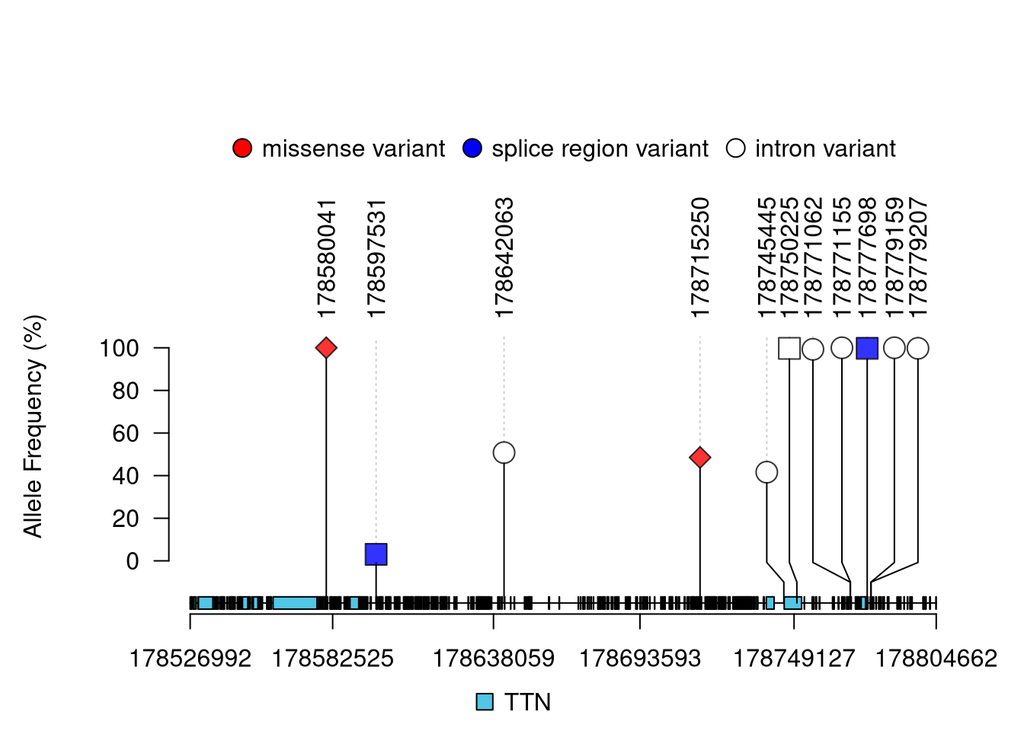

```r
# Create a function for any gene
plot_gene_lollipop <- function(gene_name, variants_df, features_list) {

  sample.gr <- GRanges(seqnames = variants_df$CHROM,
                ranges = variants_df$POS,
                AF = variants_df$AF,
                POS = variants_df$POS,
                ANN....EFFECT = variants_df$ANN....EFFECT,
                ANN....IMPACT = variants_df$ANN....IMPACT)

  features <- features_list[[gene_name]]

  #set height and color height
  features$fill <- c( "#51C6E6")
  features$height <-c(0.02)

  #set color for each node according to effect
  sample.gr$color[grepl("missense_variant", sample.gr$ANN....EFFECT)] <- "red"
  sample.gr$color[grepl("splice_region_variant", sample.gr$ANN....EFFECT)] <- "blue"

  sample.gr$alpha <- 0.8

  # set a score for each node
  sample.gr$score <- sample.gr$AF * 100

  #sample.gr$node.label <- paste0(round(sample.gr$AF * 100, 1), "%")

  # Set label position
  #sample.gr$label.parameter.pos <- 3

  # set a labels for each node according to ID
  sample.gr <- setNames(sample.gr, sample.gr$POS)
  #sample.gr$label.parameter.rot <- 45

  # set the size of node
  # Ensure no node is too small to see
  #sample.gr$cex <- 1  # Default
  #sample.gr$cex[grepl("MODERATE", sample.gr$ANN....IMPACT)] <- 1.5
  #sample.gr$cex[grepl("LOW", sample.gr$ANN....IMPACT)] <- 0.8  # Minimum 0.8, not 0.5


  available.shapes <- c("circle", "square", "diamond",
                        "triangle_point_up", "triangle_point_down")
  sample.gr$shape <- "circle"

  # Assign shapes based on impact
  sample.gr$shape[grepl("MODERATE", sample.gr$ANN....IMPACT)] <- "diamond"
  sample.gr$shape[grepl("LOW", sample.gr$ANN....IMPACT)] <- "square"

  #sample.gr$shape <- sample(available.shapes, size = length(sample.gr), replace = TRUE)
  sample.gr$legend <- paste0("legend", as.numeric(factor(sample.gr$shape)))
  # set title for the graph
  #grid.text(gene_name, x=.5, y=.98, just="top", gp=gpar(cex=1.5, fontface="bold"))

  # Plot
  lolliplot(sample.gr, features, ylab = "Allele Frequency (%)", type="circle", legend = list(labels = c("missense variant", "splice region variant", "intron variant"), fill = c("red", "blue", "white")), rescale = TRUE)
}

# Use for different genes
plot_gene_lollipop("TTN", variantsTTN, final_GRange_list)
```

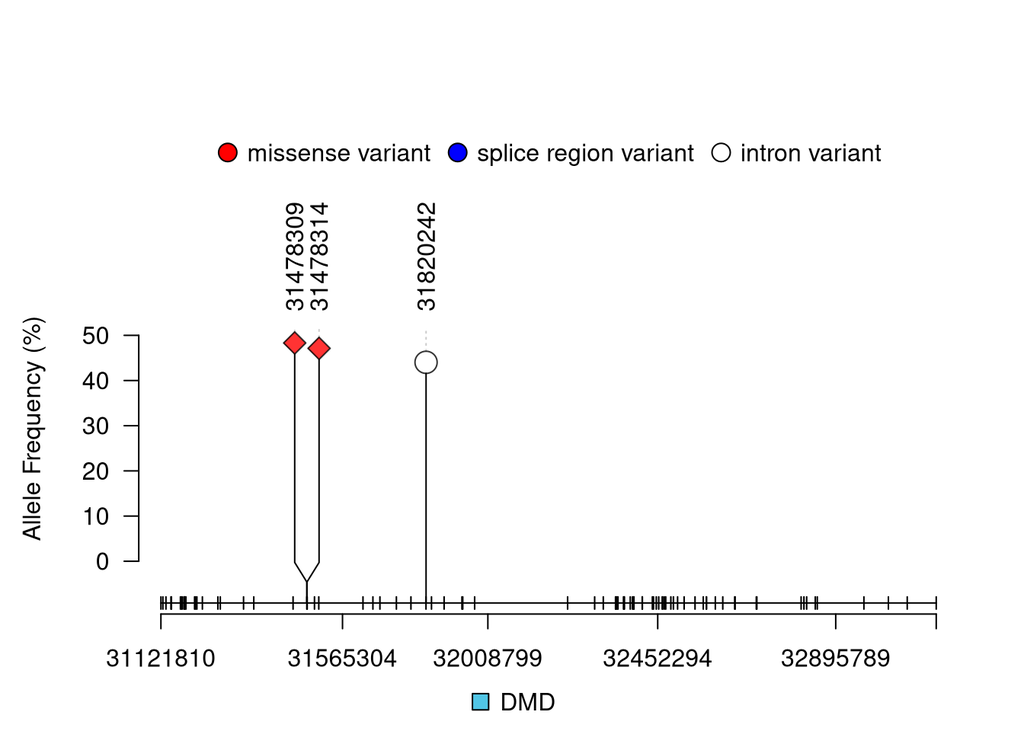

```r
plot_gene_lollipop("DMD", variantsDMD, final_GRange_list)
```

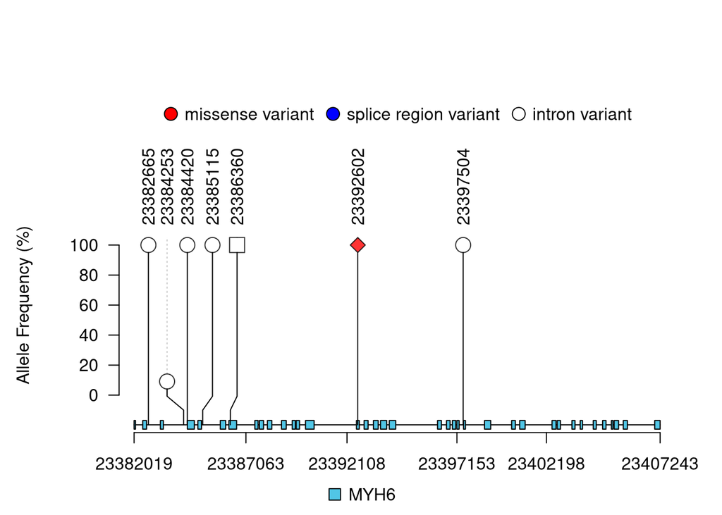

```r
plot_gene_lollipop("MYH6", variantsMYH6, final_GRange_list)
```

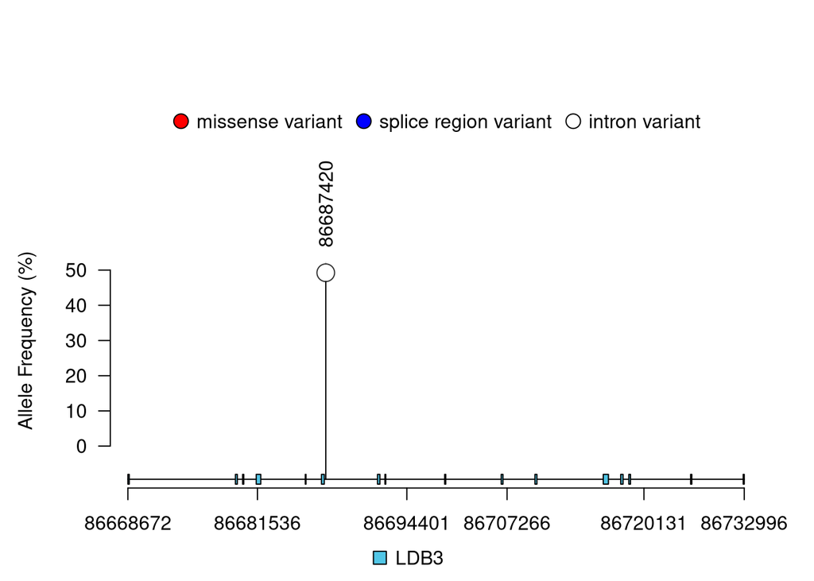

```r
plot_gene_lollipop("LDB3", variantsLDB3, final_GRange_list)
```

## Galaxy Workflow

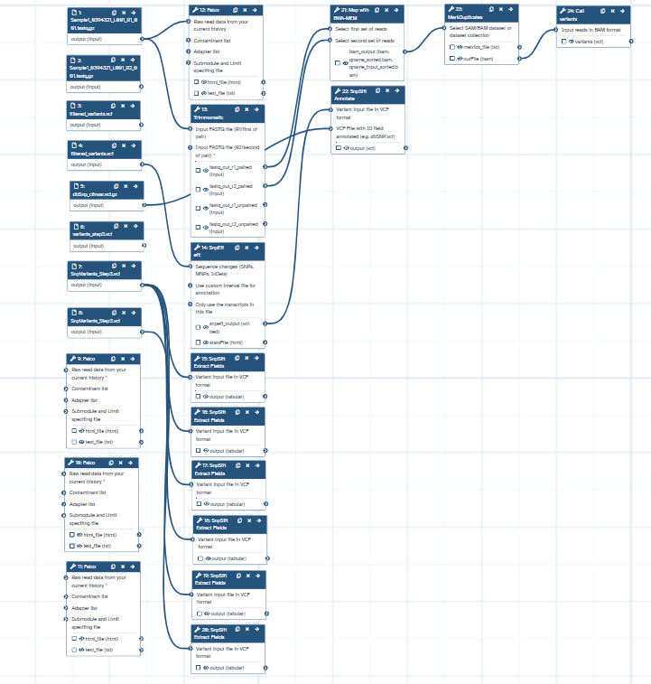

# Conclusion

This project presents a reproducible pipeline for variant discovery and prioritization in cardiomyopathy using NGS data. The workflow integrates quality control, filtering, annotation, and clinical interpretation. The identified variants provide a set of potential candidates, but further validation is required to confirm their pathogenicity.

Among the detected variants, `TTN` appears as the strongest candidate gene, while the remaining variants require further evidence before confirming pathogenicity. Validation was performed using ClinVar database annotation, supported by additional scoring systems from `dbNSFP`, `dbSNP`, and `ClinVar` annotations, which helped in assessing the clinical relevance of each variant.

This analysis has several limitations. It is based on a single sample, which limits generalizability. No functional validation was performed, so pathogenicity remains computationally inferred. Additionally, annotation scores were not consistently available across all variants, limiting direct comparison. Finally, some genes showed reduced sequencing coverage, which may lead to missed variants in low-coverage regions.